# Fitting linear mixed models in R

Wanja James

7/14/2021

# Reference

[Fitting linear mixed models in R: Brice Ozenne](http://staff.pubhealth.ku.dk/~jufo/courses/rm2018/nlmePackage.pdf)

# Packages

- `nlme package`: it enables to specify the form of the correlation structure between residuals, to model a potential heteroscedasticity and to consider random effects.  
  It is limited to Gaussian variables but can handle non-linear relationships
- `lme4 package`: it is a numerically more efficient alternative to `nlme` which is recommended for large datasets or when several random effects are considered.  
  Contrary to nlme, the correlation structure between residuals can only be model through random effects.  
  No option for dealing with heteroscedasticity other than using random effects (e.g. random slope).  
  `lme4` enables to model non-Gaussian dependent variables (e.g. binary, Poisson, . . . ).

# data set-up

```r
# Data Set-up
path <- "https://content.sph.harvard.edu/fitzmaur/ala2e/cholesterol-data.txt"
dfW.data <- read.table(file.path(path), na.string = ".")

dfW.data <- dfW.data %>%
  setNames(c("group","id","y0","y1","y2","y3","y4")) %>%
  mutate(group = factor(group,levels=1:2, labels=c("T","C")),
         group = relevel(group, ref="C"),
         id = as.factor(id))

dfL.data <- dfW.data %>%
  pivot_longer(cols=-c("group","id"),values_to="cholesterol", names_to="time")%>%
  mutate(time = str_replace(time,"[a-z]+", "visit"),
         t = as.numeric(str_extract(time,"\\d+")),
         time = relevel(as.factor(time),ref="visit0"),
         treatment = if_else(time=="visit0","none",as.character(group)),
         treatment = factor(treatment,levels=c("none","C","T"),
                            labels = c("none","pl","tr"))
         ) %>%
  arrange(id,time)
```

# dataset

| group | id | time | cholesterol | t | treatment |
| --- | --- | --- | --- | --- | --- |
| T | 1 | visit0 | 178 | 0 | none |
| T | 1 | visit1 | 246 | 1 | tr |
| T | 1 | visit2 | 295 | 2 | tr |
| T | 1 | visit3 | 228 | 3 | tr |
| T | 1 | visit4 | 274 | 4 | tr |
| T | 2 | visit0 | 254 | 0 | none |

# Using the `gls()` function of the nlme package

- `data`: specify dataset to use
- `model`: a formula, e.g. cholesterol ∼ group where:
  - the left hand side (here cholesterol) indicates the response variable $Y_i$,
  - the right hand side (here group) defines the model for the mean i.e. in $\mu(\mathbf{X}_i) = \beta X_i$ what are the explanatory variables (by default R includes an intercept).  
    In our example, the model would be $\mu(X_i) = \alpha + \beta_G \mathbb{1}_{group_i=T}$

  where $1_{group_i=T}$ is binary variable taking value $1$ if the individual $i$ belongs to the treatment group and 0 otherwise.
- `correlation, weights`: defines the covariance structure,
- `method`: defines which objective function should maximized in order to estimate the model parameters $(\beta, γ)$.
- `na.action`: indicates how to deal with missing values.

# Specifying the mean structure

### without interactions

```r
e.gls <- gls(model = cholesterol ~ group + time,
             data = dfL.data,
             na.action = na.omit)
  #  estimated mean parameters
# attributes(summary(e.gls))
summary(e.gls)$tTable
```

```
                  Value Std.Error    t-value       p-value
(Intercept) 230.4553567  5.103917 45.1526449 1.791075e-167
groupT       -0.8209958  4.291058 -0.1913271  8.483574e-01
timevisit1   14.6310680  6.225472  2.3501940  1.920343e-02
timevisit2   19.0839419  6.390793  2.9861618  2.982377e-03
timevisit3   27.1538055  6.684372  4.0622825  5.752077e-05
timevisit4   25.8663511  6.953669  3.7198134  2.251071e-04
```

# Specifying the mean structure

### without interactions …

To Interpret the estimated coefficients.

$$Y_{ij} = \alpha+\beta_G 1_{group_i=T} + \beta_{v1} 1_{j=1} + \beta_{v2} 1_{j=2} + \beta_{v3} 1_{j=3} + \beta_{v4} 1_{j=4} + \varepsilon_{ij}$$
$$\varepsilon_{ij} \sim N(0, \sigma^2)$$

where:  
$1_{group_i=T}$ is the indicator variable taking value 1 when the individual is in the treatment group and 0 otherwise.  
$1_{visit=1}$ is the indicator variable taking value 1 for the first visit and 0 otherwise.  
Note: that the design matrix is a matrix whose $i − th$ line combines one (for the intercept) with all the indicator variables for individual $i$:

$$X_i = [1, 1_{group_i=T} , 1_{j=1}, 1_{j=2}, 1_{j=3}, 1_{j=4}]$$

# Specifying the mean structure

### without interactions …

e.g, Design matrix for the 4 observations:

```r
dfL.data[c(1:2,396:397),]
```

| group | id | time | cholesterol | t | treatment |
| --- | --- | --- | --- | --- | --- |
| T | 1 | visit0 | 178 | 0 | none |
| T | 1 | visit1 | 246 | 1 | tr |
| C | 80 | visit0 | 294 | 0 | none |
| C | 80 | visit1 | 313 | 1 | pl |

```r
(X <- model.matrix(∼ group + time, data = dfL.data[c(1:2,396:397),]))
```

```
  (Intercept) groupT timevisit1 timevisit2 timevisit3 timevisit4
1           1      1          0          0          0          0
2           1      1          1          0          0          0
3           1      0          0          0          0          0
4           1      0          1          0          0          0
attr(,"assign")
[1] 0 1 2 2 2 2
attr(,"contrasts")
attr(,"contrasts")$group
[1] "contr.treatment"

attr(,"contrasts")$time
[1] "contr.treatment"
```

# Specifying the mean structure

### without interactions …

If interest is treatment effect at baseline. The effect can be written in mathematical term as:

$$E[Y_{ij}|group=T, visit = 0] - E[Y_{ij}|group=C, visit = 0]$$

The residuals have mean 0, i.e. $E[\varepsilon_{ij}]=0$, and are independent of the covariates,  
we get:

$$E[\varepsilon_{ij}|group=T, visit=0]=E[\varepsilon_{ij}|group=C, visit=0]=0$$

Applying the conditional expectation to equation (i.e. removing the residual:

$$\begin{eqnarray*}
E[Y_{ij}|group=T, visit = 0] & = & \alpha+\beta_G*1 + \beta_{v1}*0 + \beta_{v2}*0+ \beta_{v3}*0 + \beta_{v4}*0 \\[0.03in]
& = & \alpha+\beta_G \\[0.03in]
E[Y_{ij}|group=C, visit = 0] & = & \alpha+\beta_G*0 + \beta_{v1}*0 + \beta_{v2}*0+ \beta_{v3}*0 + \beta_{v4}*0 \\[0.03in]
& = & \alpha
\end{eqnarray*}$$

the treatment effect equals:

$$E[Y_{ij}|group=T, visit = 0] - E[Y_{ij}|group=C, visit = 0] = \alpha+\beta_G - \alpha = \beta_G$$

# Specifying the mean structure

### without interactions …

We can get this also from the contrast matrix, by subtracting the row corresponding to the patient from the control group at baseline to the row corresponding to the patient from the treatment group at baseline:

```r
#treatment effect at baseline
X[1,]-X[3,]
```

```
(Intercept)      groupT  timevisit1  timevisit2  timevisit3  timevisit4
          0           1           0           0           0           0
```

```r
coef(e.gls)
```

```
(Intercept)      groupT  timevisit1  timevisit2  timevisit3  timevisit4
230.4553567  -0.8209958  14.6310680  19.0839419  27.1538055  25.8663511
```

```r
sum((X[1,]-X[3,])*coef(e.gls)) #i.e estimated βG
```

```
[1] -0.8209958
```

# Specifying the mean structure

### with interactions

```r
e.glsI <- gls(model = cholesterol ~ group * time,
             data = dfL.data,
             na.action = na.omit)
  #  estimated mean parameters
summary(e.glsI)$tTable
```

```
                       Value Std.Error    t-value       p-value
(Intercept)       235.926829  6.993836 33.7335369 9.861822e-124
groupT             -9.910700  9.014429 -1.0994263  2.721875e-01
timevisit1          7.243902  9.890778  0.7323896  4.643235e-01
timevisit2          8.836329 10.084101  0.8762634  3.813683e-01
timevisit3         21.673171 10.305955  2.1029756  3.603917e-02
timevisit4         21.557042 10.658617  2.0224990  4.373343e-02
groupT:timevisit1  12.272227 12.748328  0.9626538  3.362536e-01
groupT:timevisit2  17.165724 13.057498  1.3146258  1.893252e-01
groupT:timevisit3   9.106155 13.569731  0.6710638  5.025344e-01
groupT:timevisit4   6.979461 14.097080  0.4950998  6.207785e-01
```

# Specifying the mean structure

### with interactions …

Model we have fitted for individual $i$ at visit j:

$$\begin{eqnarray*}
Y_{ij} & = & \alpha + \beta_G 1_{group_i=T} + \beta_{v1} 1_{j=1} + \beta_{v2} 1_{j=2} + \beta_{v3} 1_{j=3} + \beta_{v4} 1_{j=4} \\
& + & \beta_{I1} 1_{group_i=T}1_{j=1} + \beta_{I2} 1_{group_i=T}1_{j=2} + \beta_{I3} 1_{group_i=T}1_{j=3} + \beta_{I4} 1_{group_i=T}1_{j=4} \\
& + & \varepsilon_{ij},\varepsilon_{ij} \sim N(0, \sigma^2)
\end{eqnarray*}$$

```r
#  design matrix for the four observations
(X <- model.matrix(∼ group * time, data = dfL.data[c(1:2,396:397),]))
```

```
  (Intercept) groupT timevisit1 timevisit2 timevisit3 timevisit4
1           1      1          0          0          0          0
2           1      1          1          0          0          0
3           1      0          0          0          0          0
4           1      0          1          0          0          0
  groupT:timevisit1 groupT:timevisit2 groupT:timevisit3 groupT:timevisit4
1                 0                 0                 0                 0
2                 1                 0                 0                 0
3                 0                 0                 0                 0
4                 0                 0                 0                 0
attr(,"assign")
 [1] 0 1 2 2 2 2 3 3 3 3
attr(,"contrasts")
attr(,"contrasts")$group
[1] "contr.treatment"

attr(,"contrasts")$time
[1] "contr.treatment"
```

# Specifying the mean structure

### with interactions …

If interest is treatment effect at visit 1. The effect can be written in mathematical term as:

$$E[Y_{ij}|group=T, visit = 1] - E[Y_{ij}|group=C, visit = 1]$$

The residuals have mean 0, i.e. $E[\varepsilon_{ij}]=0$, and are independent of the covariates,  
we get:

$$E[\varepsilon_{ij}|group=T, visit=0]=E[\varepsilon_{ij}|group=C, visit=0]=0$$

Computing each term:

$$\begin{eqnarray*}
E[Y_{ij}|group=T, visit = 1] & = & \alpha+\beta_G*1 + \beta_{v1}*1 + \beta_{v2}*0+ \beta_{v3}*0 + \beta_{v4}*0 \\
& + & \beta_{I1}*1*1 + \beta_{I2}*1*0+ \beta_{I3}*1*0 + \beta_{I4}*1*0 \\
& + & 0 \\
& = & \alpha+\beta_G + \beta_{v1} + \beta_{I1} \\[0.03in]
E[Y_{ij}|group=C, visit = 1] & = & \alpha+\beta_G*0 + \beta_{v1}*1 + \beta_{v2}*0+ \beta_{v3}*0 + \beta_{v4}*0 \\
& + & \beta_{I1}*0*1 + \beta_{I2}*0*0+ \beta_{I3}*0*0 + \beta_{I4}*1*0 \\
& + & 0 \\
& = & \alpha+ \beta_{v1} \\[0.03in]
\end{eqnarray*}$$

the treatment effect equals:

$$\begin{eqnarray*}
E[Y_{ij}|group=T, visit = 1] & - & E[Y_{ij}|group=C, visit = 1] \\
& = & \alpha+\beta_G + \beta_{v1} + \beta_{I1}- \alpha - \beta_{v1} \\
& = & \beta_G + \beta_{I1}
\end{eqnarray*}$$

# Specifying the mean structure

### with interactions …

```r
# Treatment effect at visit 1
X[2,]-X[4,]
```

```
      (Intercept)            groupT        timevisit1        timevisit2
                0                 1                 0                 0
       timevisit3        timevisit4 groupT:timevisit1 groupT:timevisit2
                0                 0                 1                 0
groupT:timevisit3 groupT:timevisit4
                0                 0
```

```r
coef(e.glsI)
```

```
      (Intercept)            groupT        timevisit1        timevisit2
       235.926829         -9.910700          7.243902          8.836329
       timevisit3        timevisit4 groupT:timevisit1 groupT:timevisit2
        21.673171         21.557042         12.272227         17.165724
groupT:timevisit3 groupT:timevisit4
         9.106155          6.979461
```

```r
sum((X[2,]-X[4,])*coef(e.glsI)) #i.e estimated βG
```

```
[1] 2.361526
```

# Specifying the variance-covariance matrix

Choosing the structure of the variance-covariance matrix $\Sigma$ of the residuals:

$\varepsilon_{i} ∼ N (0,\Sigma)$

In our example, we have 5 repetitions So $\Sigma$ is a matrix with 5 rows and 5 columns.

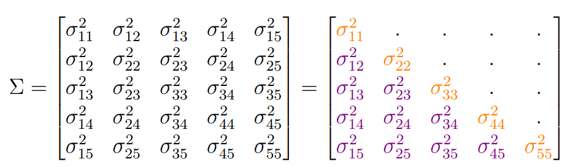

The diagonal terms tell about the variance of the residual at each time, e.g. $\sigma^2_{11}=\sigma^2_{22}$ indicates that the residual variability is the same at time 1 and 2.  
The off-diagonal terms tell about the covariance of the residual between timepoints.

# Specifying the variance-covariance matrix …

It is often easier to think in term of correlation instead of covariance. So we re-parametrize $\Sigma$:

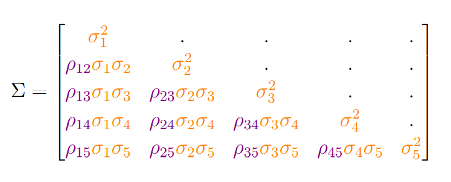

So that now we have 5 orange parameters that model the variance at each time and 10 correlation parameters that model the correlation between the residuals.

# Specifying the variance-covariance matrix …

### `gls()`

In practice `gls` uses a slightly different parameterisation:

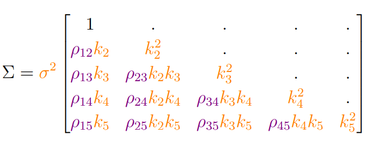

where there is a “baseline” variance level, $\sigma^2$ and the parameters $k^2_2, ...,k^2_5$ reflect the relative increase or decrease in variance over time.

# Specifying the variance-covariance matrix …

### `gls()`

gls uses 2 arguments to specify $\Sigma$:

1. `correlation`: specifies the form of the **correlation terms**. It will typically be: `corCompSymm(form = ∼ 1|subject)` or `corSymm(form = ∼ visit|subject)` and is composed of 3 parts:
   - **structure** of the correlation matrix. `corCompSymm` forces all the correlation coefficients to be equal or `corSymm` that puts no constrain. See `?corClasses` for other available structures.
   - **position** variable. This is usually not needed when using `corCompSymm` (i.e. `∼1`).  
     When using `corSymm` it is used to indicate to which repetition belong the observation (e.g. first visit or second visit, i.e. `∼ visit` where visit is a numeric variable).  
     In other structures it can be used to specify explanatory variables (e.g. geographical position)
   - **grouping** variable (.e.g `|subject`). This indicates that observations are correlated within a group and therefore jointly model all observations belonging to the same group (here to the same subject).

# Specifying the variance-covariance matrix …

### `gls()`

gls uses 2 arguments to specify $\Sigma$:

2. `weight`: specifies the form of the **variance terms**. It will typically be: `varIdent(form = ∼ 1|visit)` and is also composed of 3 parts:
   - **structure** of the variance terms. We will only use `varIdent` that uses a different variance parameter at each repetition time.
   - **position** variable. This is usually not needed when using varIdent (i.e. `∼1`).
   - **grouping** variable. This variable indicate to which repetition belong the observation (e.g. `|visit`).

# Illustration - compound symmetry structure

### `gls()`

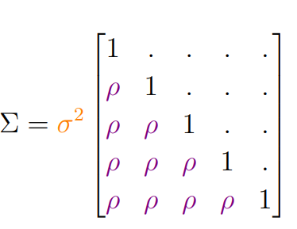

```r
e.glsCS <- gls(model = cholesterol ~ group * time,
             data = dfL.data,
             correlation = corCompSymm(form = ~1|id),
             na.action = na.omit)
  #  estimated mean parameters
# summary(e.glsCS)$tTable
logLik(e.glsCS)
```

```
'log Lik.' -2145.864 (df=12)
```

# Illustration - compound symmetry structure …

### `gls()`

Estimated Correlation parameter $\rho$

```r
summary(e.glsCS)$modelStruct$corStruct
```

```
Correlation structure of class corCompSymm representing
      Rho
0.7144955
```

and the square root of the variance parameter ($\sigma^2$):

```r
sigma(e.glsCS)
```

```
[1] 44.3852
```

# Illustration - compound symmetry structure …

### `gls()`

We can extract the residual variance-covariance matrix for the first individual using `getVarCov`

```r
(Sigma <- getVarCov(e.glsCS, individual = 1))
```

```
Marginal variance covariance matrix
       [,1]   [,2]   [,3]   [,4]   [,5]
[1,] 1970.0 1407.6 1407.6 1407.6 1407.6
[2,] 1407.6 1970.0 1407.6 1407.6 1407.6
[3,] 1407.6 1407.6 1970.0 1407.6 1407.6
[4,] 1407.6 1407.6 1407.6 1970.0 1407.6
[5,] 1407.6 1407.6 1407.6 1407.6 1970.0
  Standard Deviations: 44.385 44.385 44.385 44.385 44.385
```

and rescale it into a correlation matrix using `cov2cor`:

```r
cov2cor(Sigma)
```

```
Marginal variance covariance matrix
       [,1]   [,2]   [,3]   [,4]   [,5]
[1,] 1.0000 0.7145 0.7145 0.7145 0.7145
[2,] 0.7145 1.0000 0.7145 0.7145 0.7145
[3,] 0.7145 0.7145 1.0000 0.7145 0.7145
[4,] 0.7145 0.7145 0.7145 1.0000 0.7145
[5,] 0.7145 0.7145 0.7145 0.7145 1.0000
  Standard Deviations: 1 1 1 1 1
```

# Illustration - unstructured covariance matrix

### `gls()`

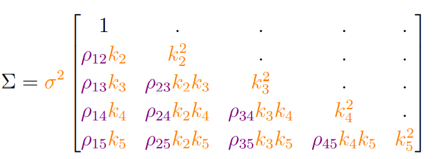

```r
e.glsUN <- gls(model = cholesterol ~ group * time,
             data = dfL.data,
             correlation = corSymm(form = ~as.numeric(time)|id),
             weights = varIdent(form = ~1|time),
             na.action = na.omit)
  #  estimated mean parameters
# summary(e.glsUN)$tTable
logLik(e.glsUN)
```

```
'log Lik.' -2132.54 (df=25)
```

# Illustration - unstructured covariance matrix …

### `gls()`

Estimated Correlation parameters $\rho_{12},\dots,\rho_{45}$

```r
summary(e.glsUN)$modelStruct$corStruct
```

```
Correlation structure of class corSymm representing
 Correlation:
  1     2     3     4
2 0.770
3 0.732 0.775
4 0.737 0.796 0.725
5 0.589 0.669 0.680 0.626
```

the inflation factors for the variance $k^2_2, ...,k^2_5$

```r
summary(e.glsUN$modelStruct$varStruct)
```

```
Variance function:
 Structure: Different standard deviations per stratum
 Formula: ~1 | time
 Parameter estimates:
   visit0    visit1    visit2    visit3    visit4
1.0000000 0.9322230 0.8798470 0.8962107 1.0303536
```

and the square root of the variance parameter ($\sigma^2$):

```r
sigma(e.glsUN)
```

```
[1] 46.76062
```

# Illustration - unstructured covariance matrix …

### `gls()`

We can extract the residual variance-covariance matrix for the first individual using `getVarCov`

```r
(Sigma <- getVarCov(e.glsUN, individual = 1))
```

```
Marginal variance covariance matrix
       [,1]   [,2]   [,3]   [,4]   [,5]
[1,] 2186.6 1570.0 1407.4 1444.5 1326.1
[2,] 1570.0 1900.2 1390.5 1454.9 1406.0
[3,] 1407.4 1390.5 1692.7 1250.1 1347.6
[4,] 1444.5 1454.9 1250.1 1756.2 1264.1
[5,] 1326.1 1406.0 1347.6 1264.1 2321.3
  Standard Deviations: 46.761 43.591 41.142 41.907 48.18
```

and rescale it into a correlation matrix using `cov2cor`:

```r
cov2cor(Sigma)
```

```
Marginal variance covariance matrix
        [,1]    [,2]    [,3]    [,4]    [,5]
[1,] 1.00000 0.77022 0.73158 0.73712 0.58863
[2,] 0.77022 1.00000 0.77530 0.79643 0.66944
[3,] 0.73158 0.77530 1.00000 0.72504 0.67985
[4,] 0.73712 0.79643 0.72504 1.00000 0.62609
[5,] 0.58863 0.66944 0.67985 0.62609 1.00000
  Standard Deviations: 1 1 1 1 1
```